# Análisis Covid19 en Chile: Corrección por población

DataIntelligence

12-05-2020

### Se construye un indicador consistente en dividir los casos por la poblacion multiplicado por 100000 (tasa de incidencia acumulada).

### Comunas que superaron el límite de 250 unidades TIA para los acumulados corregidos:

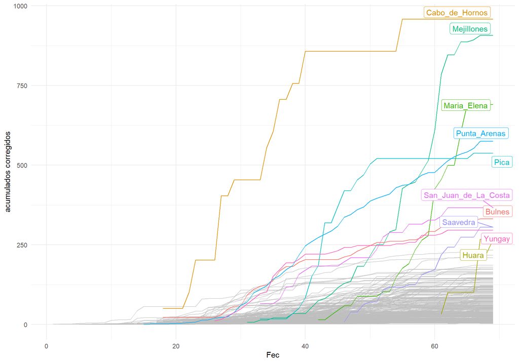

### Comunas que en algun momento superaron las 150 unidades TIA para los activos corregidos:

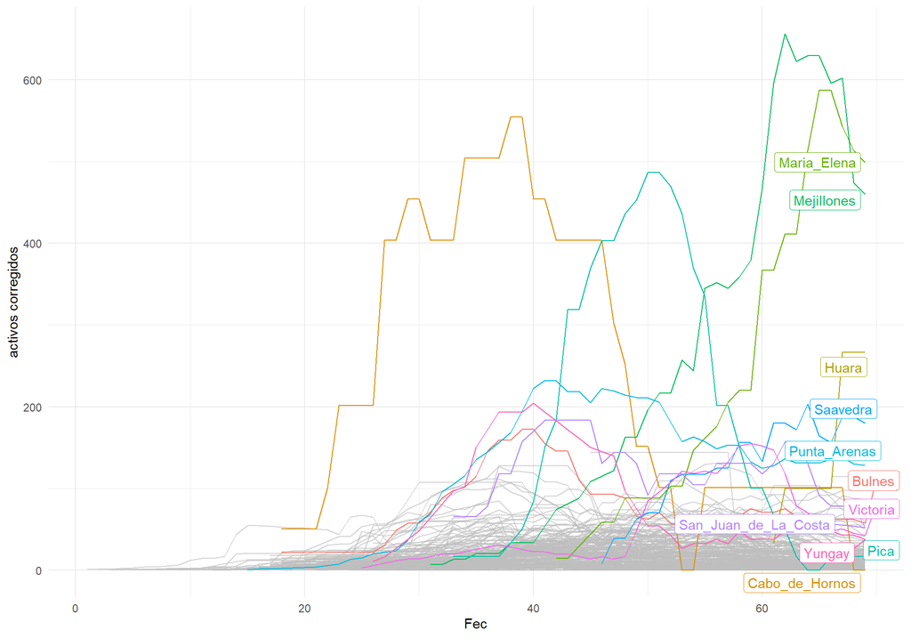

### Dendrograma circular de los CASOS ACUMULADOS CORREGIDOS de Covid19 en las comunas de Chile, agrupados en 6 clusters, del 3 de Marzo al 10 de Mayo del 2020

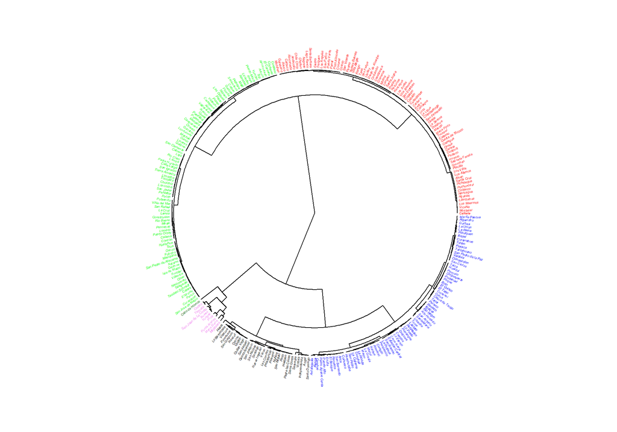

### Medias condicionales suavizadas (smoothed conditional means) utilizando el metodo LOESS:

#### La regresión local o regresión polinómica local, también conocida como regresión móvil, es una generalización de la media móvil y la regresión polinómica. Sus métodos más comunes, desarrollados inicialmente para el suavizado del diagrama de dispersión, son LOESS (suavizado de diagrama de dispersión estimado localmente) y LOWESS (suavizado de diagrama de dispersión ponderado localmente)

#### Grupo 1: Riesgo altísimo.

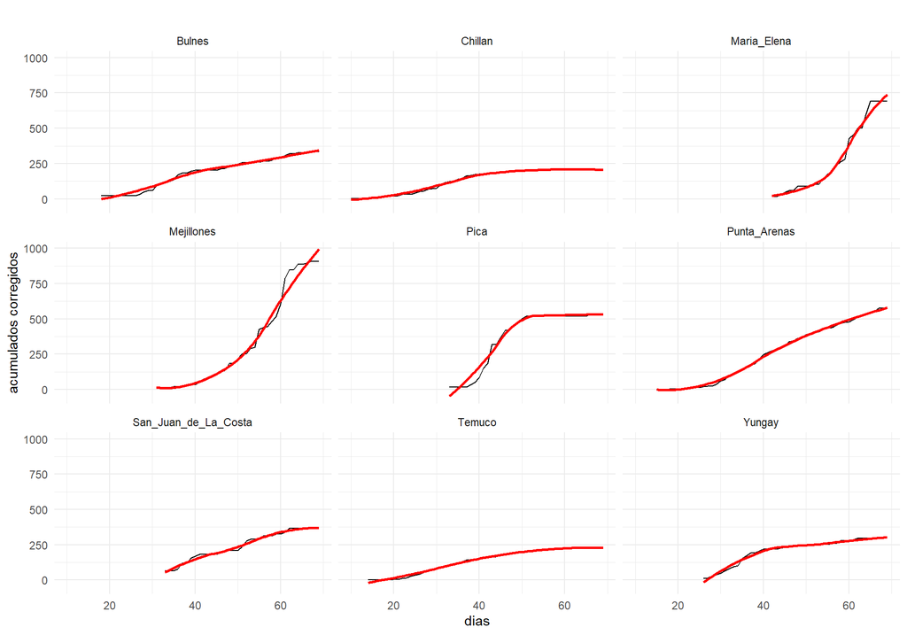

#### Grupo 2: Riesgo alto.

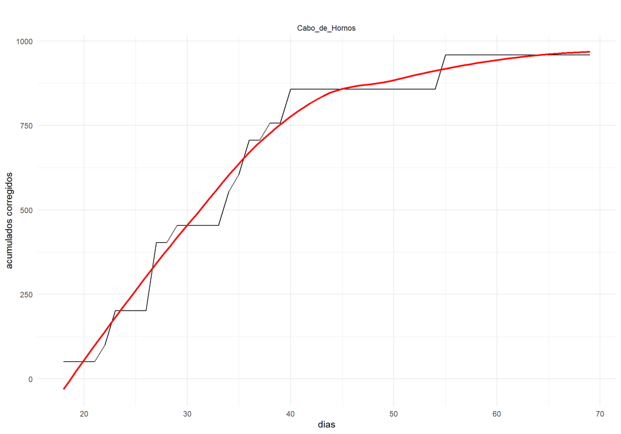

#### Grupo 3: Riesgo medio alto.

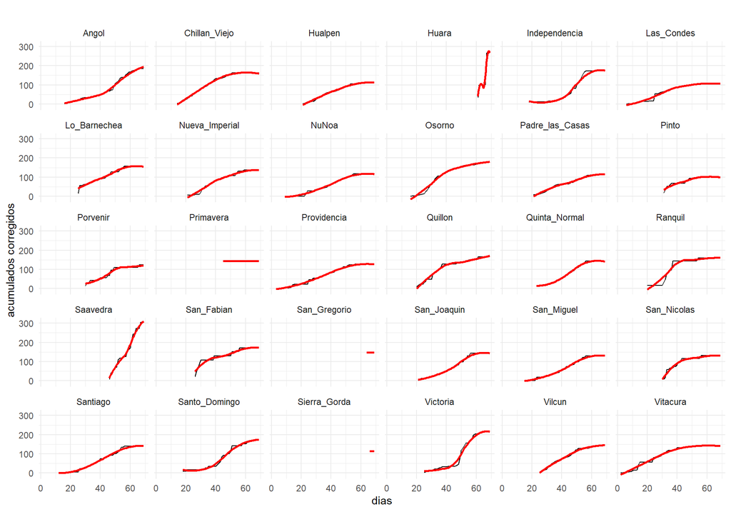

#### Grupo 4: Riesgo medio bajo.

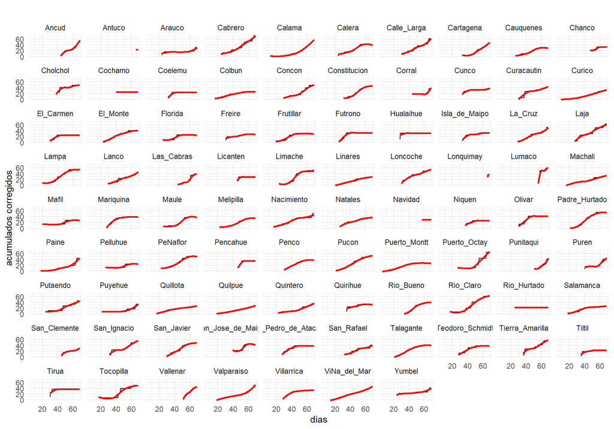

#### Grupo 5: Riesgo bajo.

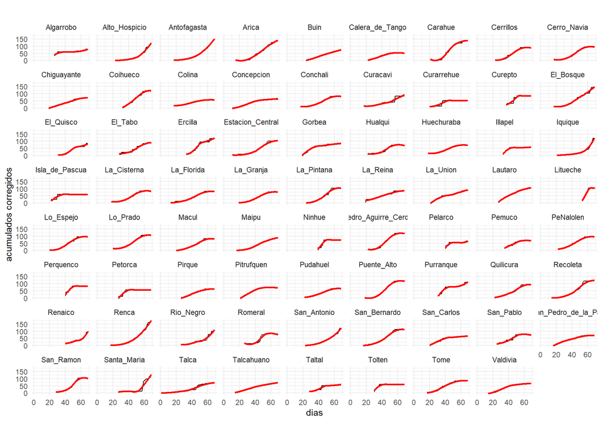

#### Grupo 6: Riesgo bajísimo.

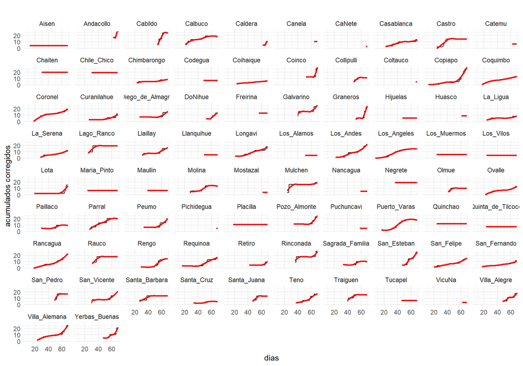

### Dendrograma circular de los CASOS ACTIVOS CORREGIDOS de Covid19 en las comunas de Chile, agrupados en 6 clusters, del 3 de Marzo al 10 de Mayo del 2020

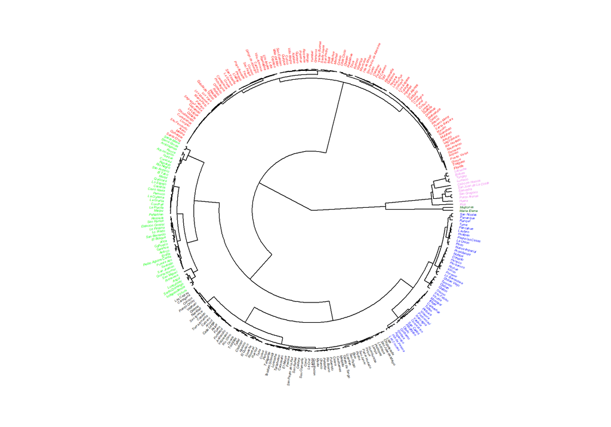

#### Grupo 1: Riesgo altísimo.

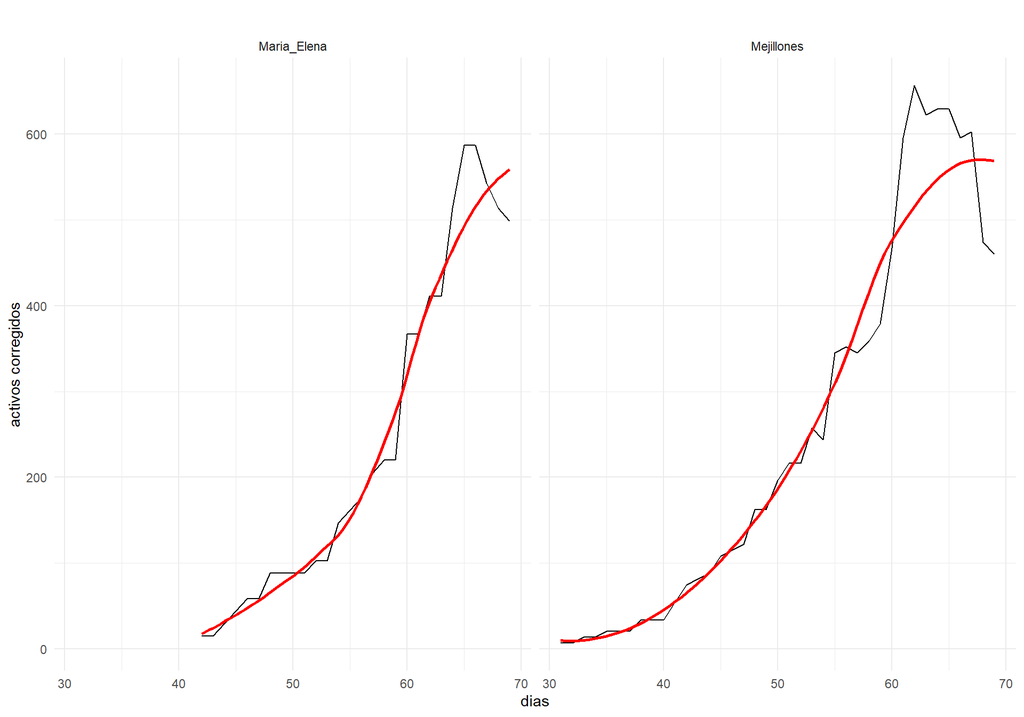

#### Grupo 2: Riesgo alto.

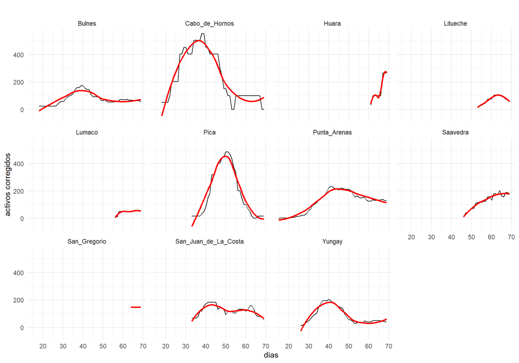

#### Grupo 3: Riesgo medio alto.

[figure not shown]

#### Grupo 4: Riesgo medio bajo.

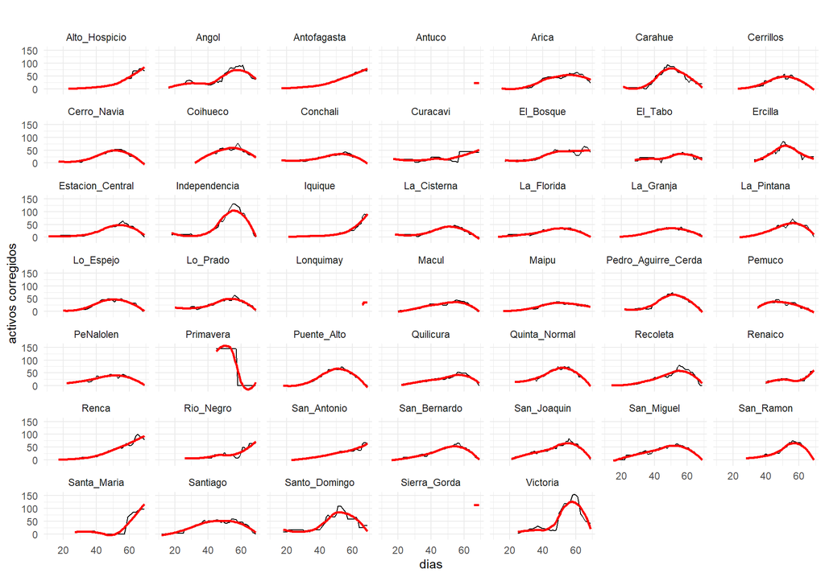

#### Grupo 5: Riesgo bajo.

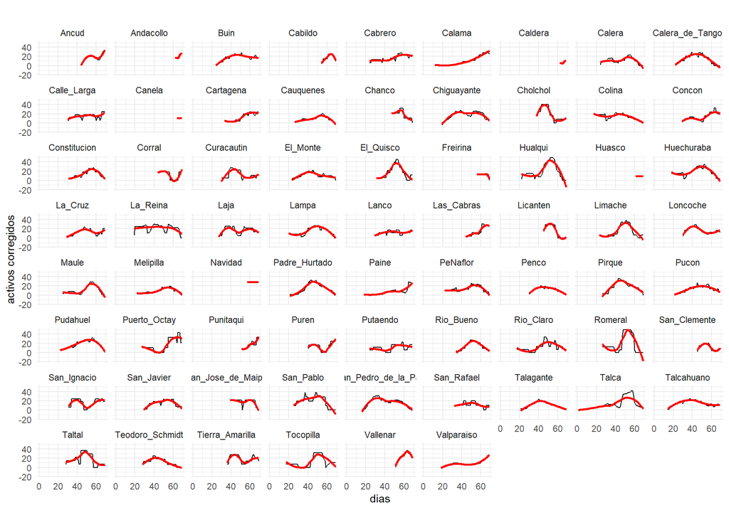

#### Grupo 6: Riesgo bajísimo.

[figure not shown]